# Big data analysis and visualisation: Session 2

Acquiring, preparing, and visualizing data

J.M.T. Roos

Last updated: 2017-05-08 11:55:17

# Review

- In class
  - git — cloning, committing, pushing
  - R Markdown — mixing text with R code using `` ```{r} `` blocks
- During the week
  - Reviewing/learning the R programming language
  - Installing packages

# Applied problem: Merging samples

Repeated measures for 11 individuals, mean (sd)

| Round | Duration | Number Correct |
| --- | --- | --- |
| 1 | 7.5 | 9.0 |
|  | (2.0) | (3.3) |
| 2 | 7.5 | 9.0 |
|  | (2.0) | (3.3) |
| 3 | 7.5 | 9.0 |
|  | (2.0) | (3.3) |
| 4 | 7.5 | 9.0 |
|  | (2.0) | (3.3) |

# Applied problem: Merging samples

Regression of `Duration` on `Number Correct` repeated for each round

| Round | Term | Estimate | SE |
| --- | --- | --- | --- |
| 1 | (Intercept) | 3.0 | 1.12 |
|  | num.correct | 0.5 | 0.12 |
| 2 | (Intercept) | 3.0 | 1.13 |
|  | num.correct | 0.5 | 0.12 |
| 3 | (Intercept) | 3.0 | 1.12 |
|  | num.correct | 0.5 | 0.12 |
| 4 | (Intercept) | 3.0 | 1.12 |
|  | num.correct | 0.5 | 0.12 |

# This session

- Data visualization with `ggplot2`
  - Basics
  - In-class exercises
  - More advanced concepts
  - In-class exercises
- Tidying and summarizing data with `dplyr`, `reshape2`, and `tidyr`
  - Single table operations
  - In-class exercises
  - Joins
  - In-class exercises
- Acquiring (tabular) data (*briefly covered*)

# ggplot2

- Plotting package in R intended to replace the core plotting routines
- Based on the concept of a **grammar of graphics**
  - Plots are constructed from simpler components, much as sentences are constructed from nouns, verbs, etc.
  - Not all arrangements of words lead to comprehensible sentences — the same is true for plots, and ggplot2 helps you avoid (visual) nonsense
  - This approach leads to a modularity of design, making it easy for programmers to extend
- Sensible and aesthetically pleasing default settings
  - Informed by what we know about visual perception and cognition

# What is a graph?

> A visual display that illustrates one or more relationships among numbers…a shorthand means of presenting information that would take many more words and numbers to describe.

> —Stephen M. Kosslyn. Graph Design for the Eye and Mind. Oxford University Press, 2006

It depends on the goal:

- A tool for discovery — gain an overview of, convey the scale and complexity of, or facilitate an exploration of **data** (*dataviz*)
- A tool for communication — help you to help others understand, tell a story about, or stimulate interest in a **problem or solution** (*infographics*)

# At a minimum…

- Graphs are for comparing quantities
  - Always ask yourself: “Comparing what?”
  - Insist on this comparison being obvious to the viewer (and yourself)
- Each graph should answer a central question
  - Both the question and answer should be clear
  - Use the title, caption, and other labels to highlight both
    - For manuscripts, these text elements are excluded from your word count, and you should take advantage of that

# Psychological principles (Kosslyn, 2006)

- I will briefly cover some of what we know about human cognition of data visualizations
- If you want to know more, the book by Kosslyn (see quote earlier) is a good reference
- Book divides what we know into 8 principles, which I think fall into 3 buckets:
  - Connecting with the audience
  - Directing and holding attention
  - Promoting understanding and memory

# Connecting with the audience

1. **Relevance**
   - Not too much or too little information
   - Present information that reflects the message you want to convey
   - Don’t present extraneous information
2. **Appropriate knowledge**
   - Prior knowledge must be sufficient to understand the graph
   - If you assume too much prior knowledge, viewers will be confused
   - If you violate norms, viewers will be confused

# Directing and holding attention

3. **Salience**
   - Attention is drawn to large perceptible differences
   - The most visually striking aspect receives the most attention
   - Annotations help direct viewers’ attention
4. **Discriminability**
   - Properties must differ enough to be noticed
   - Defaults in `ggplot2` do much of this work for you
5. **Organization**
   - Groups of elements are seen and remembered as a whole

# Understanding and memory

6. **Compatibility**
   - Form should be aligned with meaning
   - Lines express continuous change, bars discrete quantities
   - More = more (higher, better, bigger, etc.)
7. **Informative changes**
   - Changes in properties should carry information
   - …and vice versa
8. **Capacity limitations**
   - If too much information is presented, none is remembered
   - Four chunks in working memory
   - Graph designers err on the side of presenting too much, graph readers err on the side of paying too little attention

# ggplot2’s grammar

- Decomposes graphs into basic parts
- Sets rules for interactions among those parts
- Helps us stay out of trouble

# ggplot2’s grammar

- **Default** values for **Data** and **Mapping** available to all layers
- **Layers** — one or more, each with the following:
  - **Data** (overriding the default) — a `data.frame`
  - **Mapping** (overriding the default) of columns to **Aesthetics**
  - **Geometry** specifying what to draw
  - **Statistic** specifying how to transform the data before drawing
  - **Position** specifying how to arrange items
- **Facet** specification for generating subplots
- **Scales** specifying how to translate the data to lengths, colors, sizes, etc. in the graph
- **Coordinates** which is the default (Cartesian) 99% of the time, so ignore for now

# Layers

- Layers contain everything we see, often showing different views of the same data

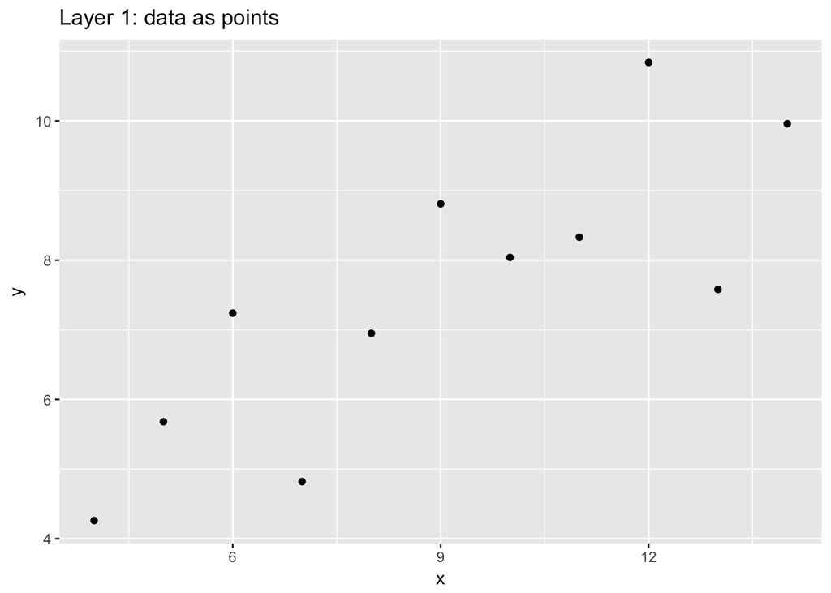

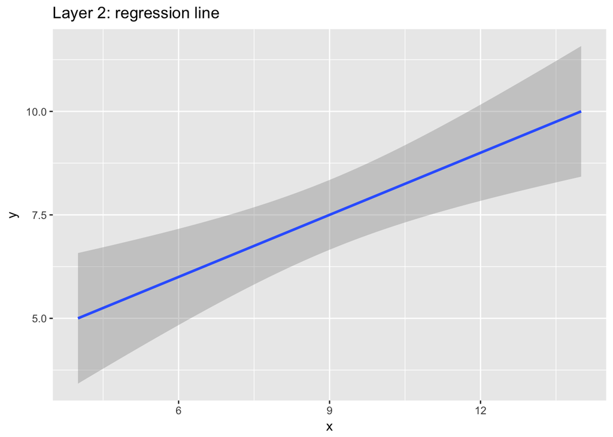

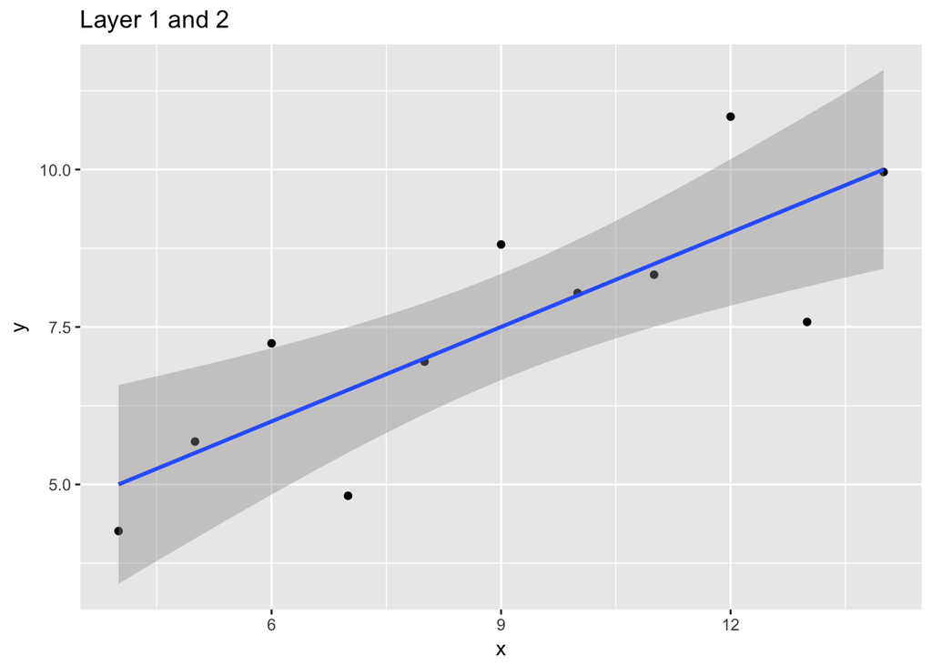

# Test data

```r
test_data
```

```
## # A tibble: 44 × 4
##     round respondent num.correct duration
##    <fctr>     <fctr>       <dbl>    <dbl>
## 1       1          1          10     8.04
## 2       1          2           8     6.95
## 3       1          3          13     7.58
## 4       1          4           9     8.81
## 5       1          5          11     8.33
## 6       1          6          14     9.96
## 7       1          7           6     7.24
## 8       1          8           4     4.26
## 9       1          9          12    10.84
## 10      1         10           7     4.82
## # ... with 34 more rows
```

# Defaults

- Specify the defaults first
- Most graphs use a single set of **data** (`data.frame`) for every layer
- Most graphs use a single set of **mapping**s between columns and aesthetics

```r
my_plot <- ggplot(data = test_data, mapping = aes(x = duration,
    y = num.correct))
```

- `aes()` is used to create a list of `aes`thetic mappings
  - `x` refers to the graph’s x-axis, `y` to the y-axis
  - `duration` $\rightarrow$ x-axis
  - `num.correct` $\rightarrow$ y-axis
- `my_plot` now represents a `ggplot` object set to our defaults
- You don’t need to name the arguments; `data` comes first, `mapping` comes second

```r
my_plot <- ggplot(test_data, aes(x = duration, y = num.correct))
```

# An empty plot

- Defaults by themselves do nothing

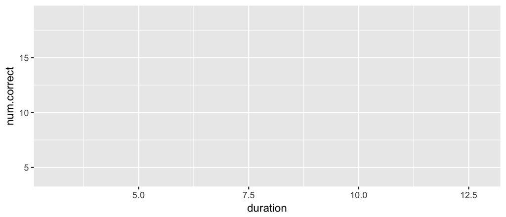

```r
print(my_plot)
```

- By default, we get an “empty” plot
- To see something, we need to specify a layer

# Adding a layer

- Use the `+` operator to combine ggplot elements

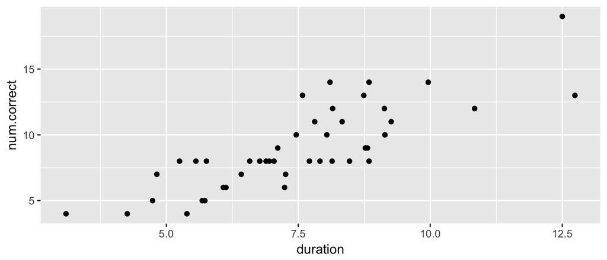

```r
my_plot + geom_point()
```

- Usually you do not need the `print()` call, so the following two lines are equivalent:

  ```r
  my_plot + geom_point()
  print(my_plot + geom_point())
  ```

# Each layer has a geometry

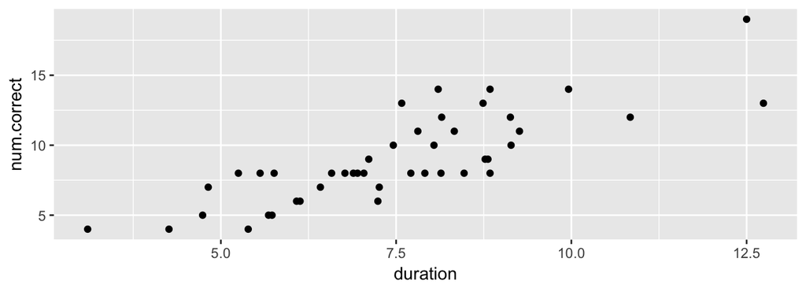

```r
my_plot + geom_point()
```

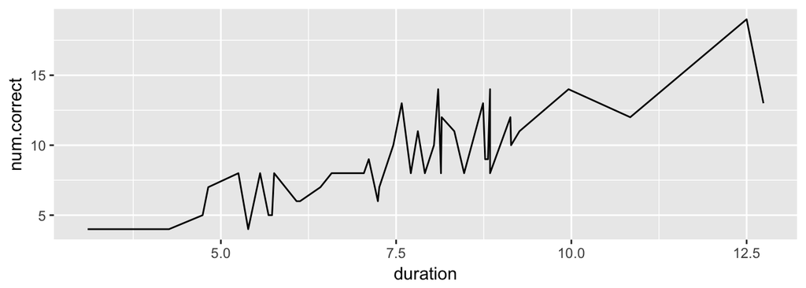

```r
my_plot + geom_line()
```

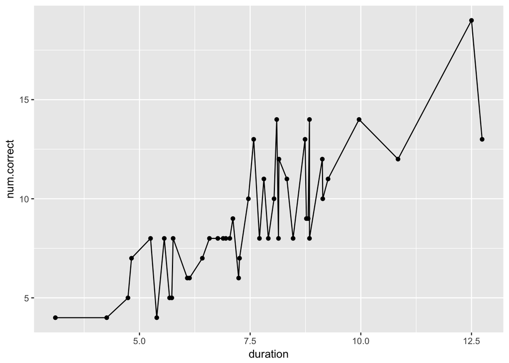

```r
my_plot + geom_point() + geom_line()
```

# Each layer has a statistic

- Usually the statistic is the `identity` function,
  $$f(x)=x$$
  That is, the data are left unchanged
- The default statistic for `geom_point` and `geom_line` is `identity` so these plots show the data as is
- The default statistic for `geom_histogram` is a binning function (called `stat_bin`)

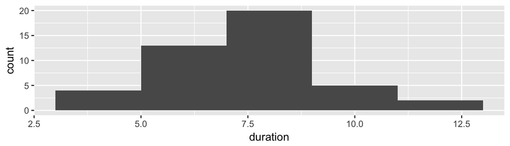

```
## # A tibble: 44 × 4
##     round respondent num.correct duration
##    <fctr>     <fctr>       <dbl>    <dbl>
## 1       1          1          10     8.04
## 2       1          2           8     6.95
## 3       1          3          13     7.58
## 4       1          4           9     8.81
## 5       1          5          11     8.33
## 6       1          6          14     9.96
## 7       1          7           6     7.24
## 8       1          8           4     4.26
## 9       1          9          12    10.84
## 10      1         10           7     4.82
## # ... with 34 more rows
## # A tibble: 5 × 2
##       x     y
##   <dbl> <dbl>
## 1     4     4
## 2     6    13
## 3     8    20
## 4    10     5
## 5    12     2
```

```r
ggplot(test_data, aes(x = duration)) + geom_histogram(binwidth = 2)
```

# Geoms and statistics

- Each geom/statistic has a default statistic/geom

| Item | Default stat/geom |
| --- | --- |
| `geom_point` | `stat_identity` ($f(x)=x$) |
| `geom_line` | `stat_identity` ($f(x)=x$) |
| `geom_histogram` | `stat_bin` (binning) |
| `geom_smooth` | `stat_smooth` (regression) |
| `stat_smooth` | `geom_smooth` (line + ribbon) |
| `stat_bin` | `geom_bar` (vertical bars) |
| `stat_identity` | `geom_point` (dots) |

- Hence, these produce the same output:

  ```r
  ggplot(test_data, aes(x = duration)) + stat_bin(binwidth = 1)
  ggplot(test_data, aes(x = duration)) + geom_histogram(binwidth = 1)
  ```

# Data versus statistics

- Be sure you understand: “Does this layer contain data or statistics?”
- When in doubt, prefer data to statistics:
- Example: A scatter plot of observations conveys more information than a box plot showing quantiles

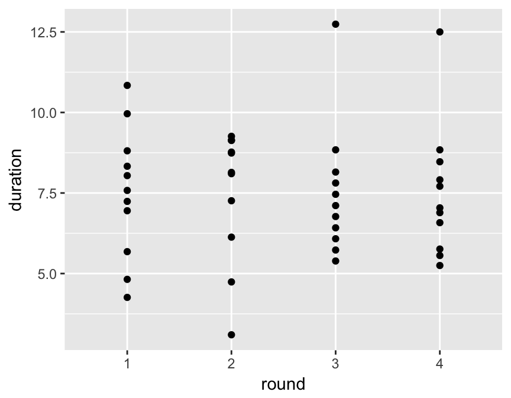

```r
ggplot(test_data, aes(x = round,
  y = duration)) + geom_point()
```

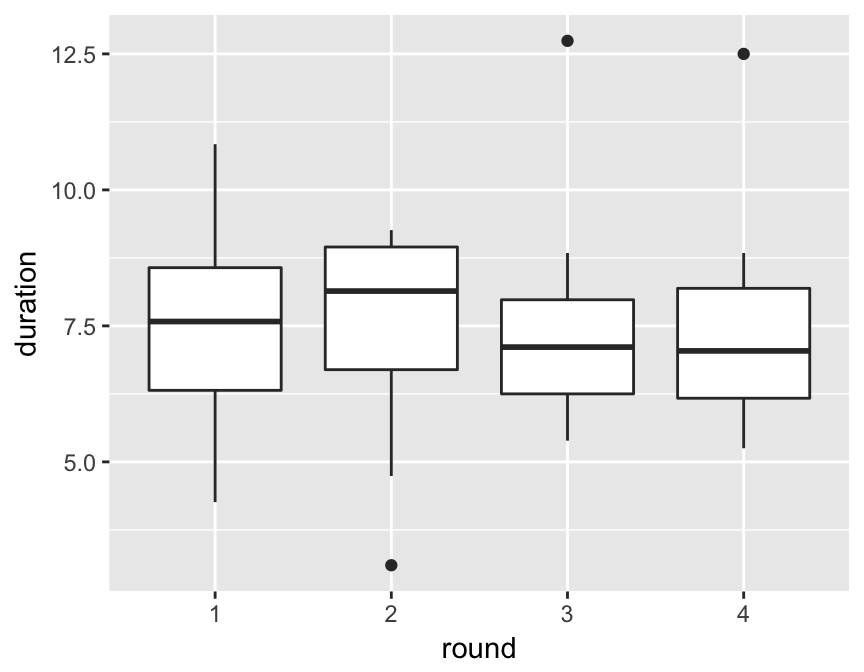

```r
ggplot(test_data, aes(x = round,
  y = duration)) + geom_boxplot()
```

# Aesthetics

- Each geometry interacts with one or more aesthetics

| Item | Required | Optional |
| --- | --- | --- |
| `geom_point` | `x`, `y` | `alpha`, `colour`, `fill`, `shape`, `size`, `stroke` |
| `geom_line` | `x`, `y` | `alpha`, `colour`, `linetype`, `size` |
| `geom_pointrange` | `x`, `ymax`, `ymin` | `alpha`, `colour`, `linetype`, `size` |

- You can either **map** data to an aesthetic, or **set** it explicitly

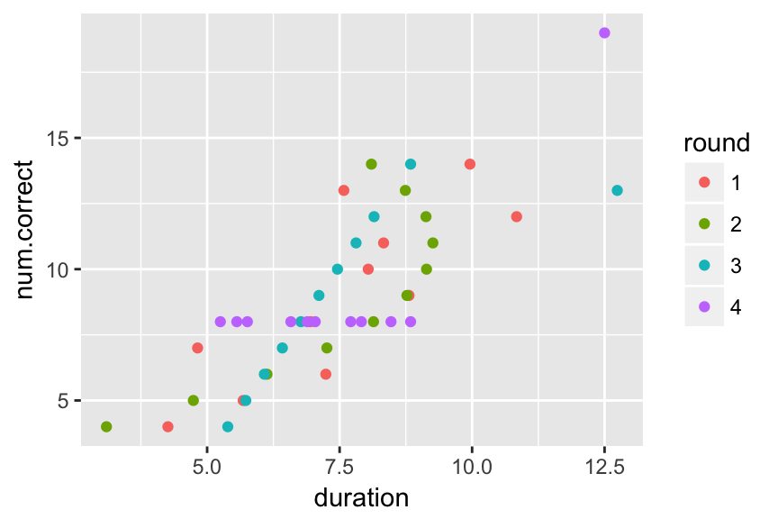

```r
my_plot + geom_point(
  mapping = aes(colour = round))
```

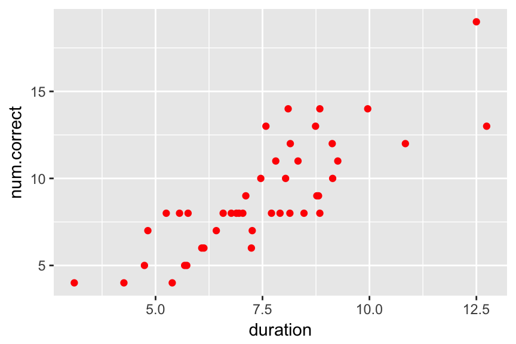

```r
my_plot + geom_point(
  colour="red")
```

# Position

- Each layer also has a position specification
- The default is again `identity` meaning don’t do anything special
- Examples: bars can be positioned with `stack` or `dodge`

```r
g <- ggplot(test_data, aes(x = num.correct, fill = round))
```

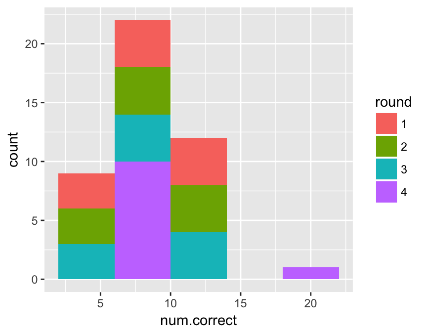

```r
g + stat_bin(binwidth = 4,
             position = 'stack')
```

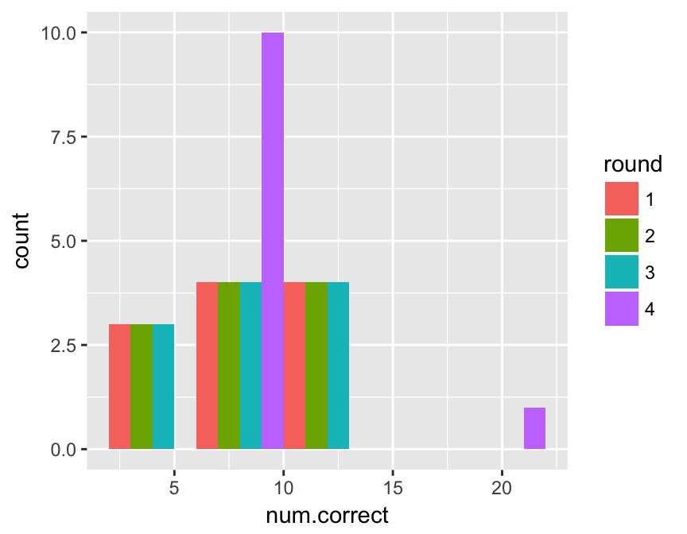

```r
g + stat_bin(binwidth = 4,
             position = 'dodge')
```

# Practice with layers (Tasks 1–4)

- Work with a neighbor
- First discuss the task, then one of you does the typing (take turns for each task)
- Discuss what you are doing as you write code
- Write your code in an empty **File > New File… > R Script** and execute each line using `Cmd-Enter` (Mac) or `Control-Enter` (Windows)
- Use the data set called `mpg` which is included in the `ggplot2` package
- Exercises can be found at http://jasonmtroos.com/assets/media/teaching/rook/session_2_in_class.html or `http://goo.gl/Gx5LAK`

# Data

```r
library(ggplot2) #library(tidyverse)
?mpg
```

## Fuel economy data from 1999 and 2008 for 38 popular models of car

### Description

This dataset contains a subset of the fuel economy data that the EPA makes available on http://fueleconomy.gov. It contains only models which had a new release every year between 1999 and 2008 - this was used as a proxy for the popularity of the car.

### Usage

```
mpg
```

### Format

A data frame with 234 rows and 11 variables

**manufacturer**

**model**

model name

**displ**

engine displacement, in litres

**year**

year of manufacture

**cyl**

number of cylinders

**trans**

type of transmission

**drv**

f = front-wheel drive, r = rear wheel drive, 4 = 4wd

**cty**

city miles per gallon

**hwy**

highway miles per gallon

**fl**

fuel type

**class**

“type” of car

```r
mpg
```

```
## # A tibble: 234 × 11
##    manufacturer      model displ  year   cyl      trans   drv   cty   hwy
##           <chr>      <chr> <dbl> <int> <int>      <chr> <chr> <int> <int>
## 1          audi         a4   1.8  1999     4   auto(l5)     f    18    29
## 2          audi         a4   1.8  1999     4 manual(m5)     f    21    29
## 3          audi         a4   2.0  2008     4 manual(m6)     f    20    31
## 4          audi         a4   2.0  2008     4   auto(av)     f    21    30
## 5          audi         a4   2.8  1999     6   auto(l5)     f    16    26
## 6          audi         a4   2.8  1999     6 manual(m5)     f    18    26
## 7          audi         a4   3.1  2008     6   auto(av)     f    18    27
## 8          audi a4 quattro   1.8  1999     4 manual(m5)     4    18    26
## 9          audi a4 quattro   1.8  1999     4   auto(l5)     4    16    25
## 10         audi a4 quattro   2.0  2008     4 manual(m6)     4    20    28
## # ... with 224 more rows, and 2 more variables: fl <chr>, class <chr>
```

# Task 0 (Example)

- Create a plot with 1 layer:
  - `x` mapped to `cty`
  - `y` mapped to `hwy`
  - `point` geometry
  - `identity` stat
  - `identity` position

# Basic exercises (Tasks 1–4)

- http://jasonmtroos.com/assets/media/teaching/rook/session_2_in_class.html
- `http://goo.gl/Gx5LAK`

# Facets and discrete groups

- Two main options when comparing subsets of data
  - Each discrete set is given a different `colour`, `shape`, or `size`
  - Each discrete set is plotted in its own `facet`

```r
g <- ggplot(mpg, aes(x = displ, y = hwy))
```

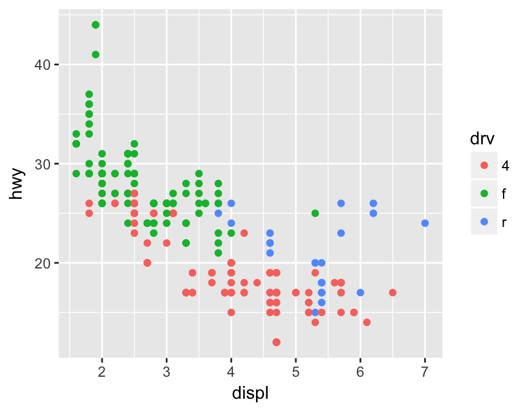

```r
g + geom_point(aes(colour = drv))
```

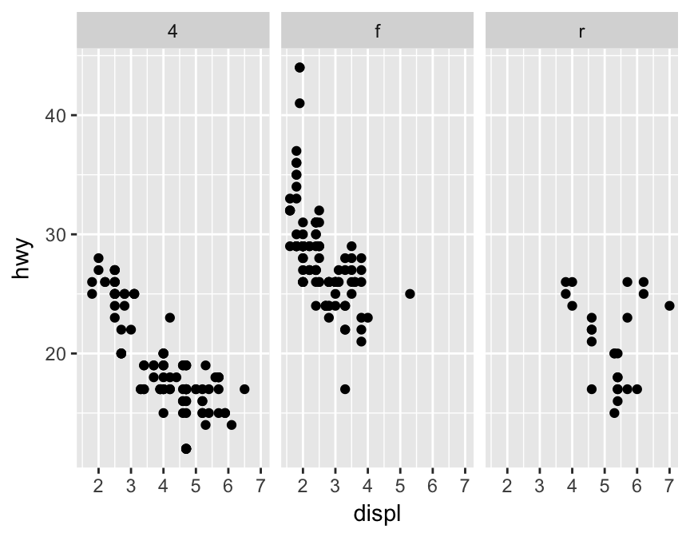

```r
g + geom_point() + facet_wrap(~drv)
```

# Groups

- When you map discrete variables to `colour`, `shape`, or `size`, ggplot2 automatically maps those variables to `group`
- The `group` aesthetic controls how collections of items are rendered
  - In `geom_line` the `group` aesthetic determines which points will be connected by a continuous line
  - In `stat_summary` the `group` aesthetic determines which points are summarised by a common statistic
- If a variable `v` is continuous but you want to use it for grouping, either specificy `group = v` or transform it into a discrete variable, e.g., `colour = factor(v)`

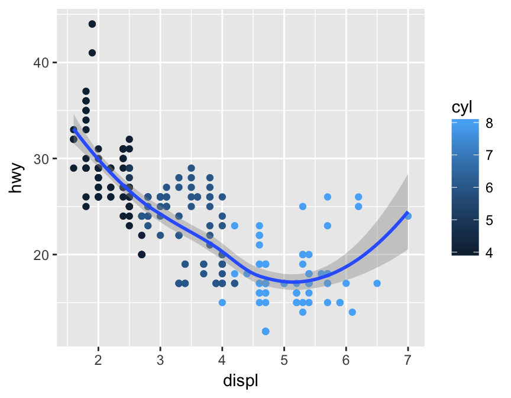

```r
ggplot(mpg, aes(x = displ, y = hwy,
              colour=cyl)) +
  geom_point() + geom_smooth()
```

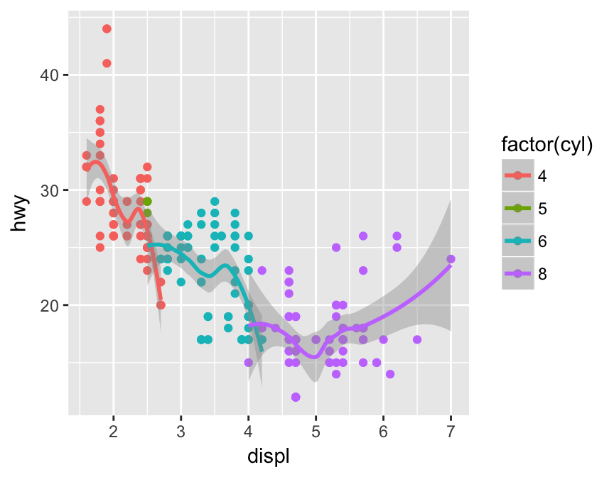

```r
ggplot(mpg, aes(x = displ, y = hwy,
              colour=factor(cyl))) +
  geom_point() + geom_smooth()
```

- To override the automatic grouping, specify `aes(group=1)` when creating a layer

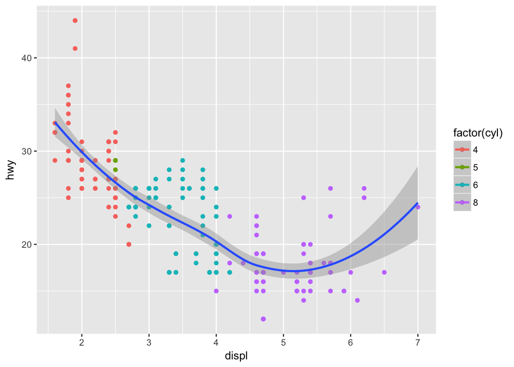

```r
ggplot(mpg, aes(x = displ, y = hwy, colour = factor(cyl))) +
    geom_point() + geom_smooth(aes(group = 1))
```

# Scales

- Scales apply to the entire plot, i.e., to every layer
- ggplot2 can detect what type of scale you might want, but it isn’t perfect
- For example, you might want a logarithmic scale instead of the default linear scale

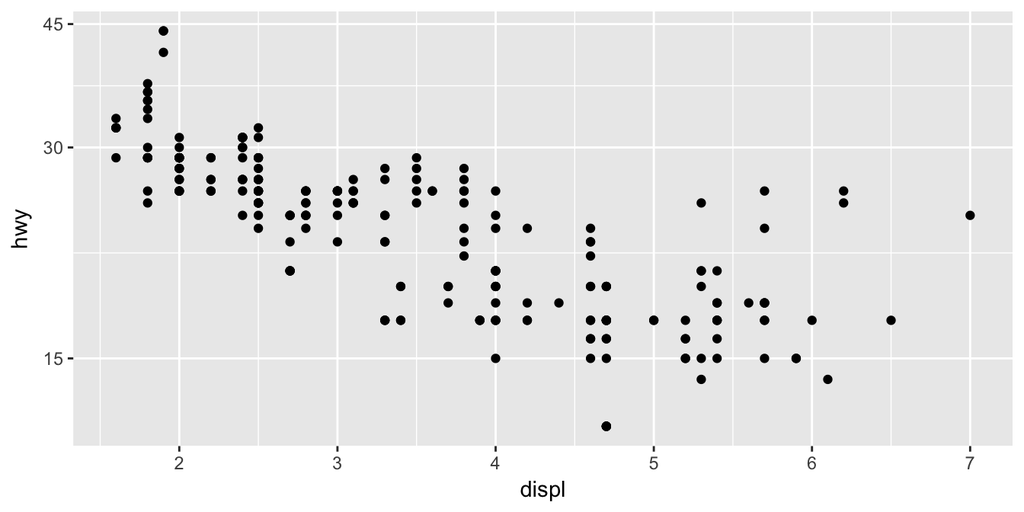

```r
ggplot(mpg, aes(x = displ, y = hwy)) + geom_point() +
    scale_y_log10(breaks = c(15, 30, 45))
```

# Labels

- Always annotate graphs with a title and human-readable labels for each aesthetic
  - x- and y-axes
  - Legends and colour bars

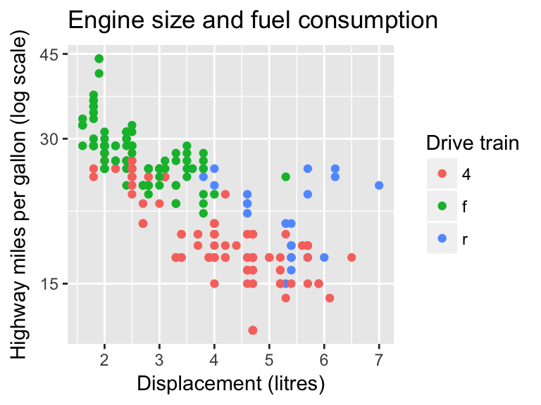

```r
ggplot(mpg, aes(x = displ, y = hwy, colour = drv)) + geom_point() +
    scale_y_log10(breaks = c(15, 30, 45)) + labs(x = "Displacement (litres)",
    y = "Highway miles per gallon (log scale)",
    colour = "Drive train",
    title = "Engine size and fuel consumption")
```

# Relabelling

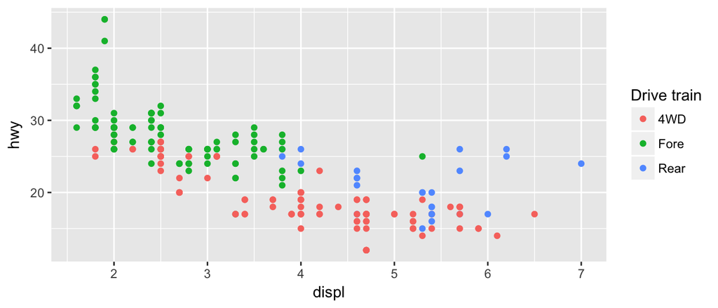

```r
ggplot(mpg, aes(x = displ, y = hwy, colour = plyr::revalue(drv,
    c(f = "Fore", r = "Rear", `4` = "4WD")))) + geom_point() +
    labs(colour = "Drive train")
```

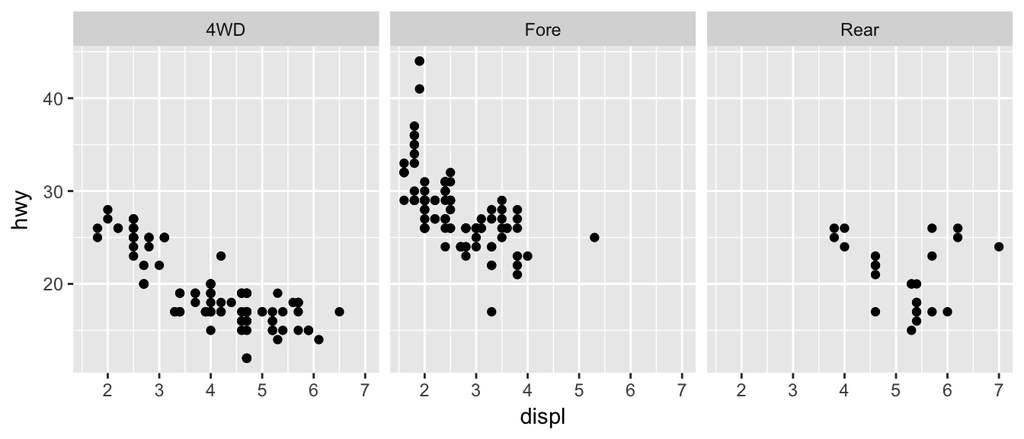

```r
ggplot(mpg, aes(x = displ, y = hwy)) + geom_point() +
    facet_wrap(~drv, labeller = as_labeller(c(f = "Fore",
        r = "Rear", `4` = "4WD")))
```

# Task 5

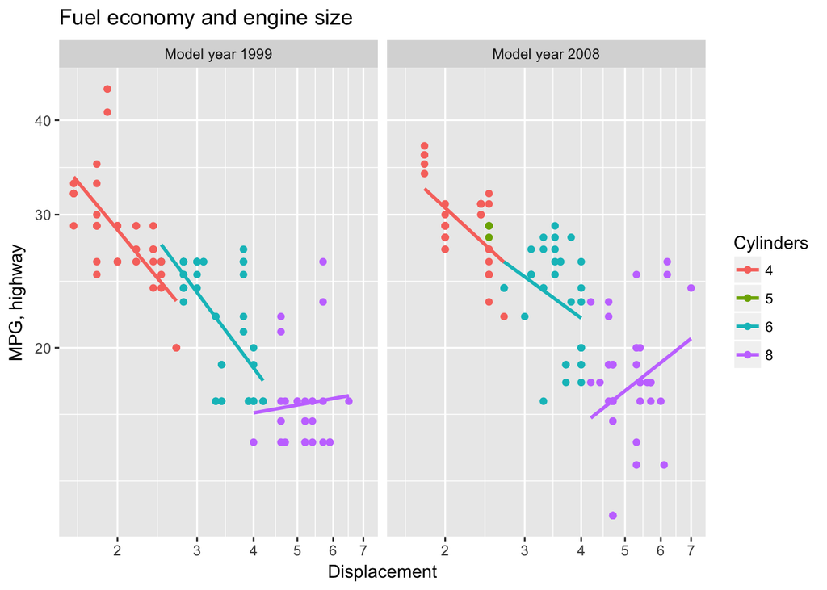

# More reading

- See the [ggplot2 documentation](http://docs.ggplot2.org/current/) for a visual summary of the available geometries, list of stats, and more; as well as detailed documentation
- [STAT 545 @ UBC](http://stat545.com/topics.html) is an in-depth course covering a lot of the same material we cover here, including ggplot2 and dplyr
- [Chapter 3 of R for Data Science](http://r4ds.had.co.nz/data-visualisation.html) has a very nice introduction to ggplot2 that follows a similar flow to what we covered today
- [39 studies about human perception in 30 minutes](https://medium.com/@kennelliott/39-studies-about-human-perception-in-30-minutes-4728f9e31a73) is a nice review of what we know about perception of data visualizations

# Tidying and summarizing data

- Single table operations
- Joins

# dplyr

```r
library(dplyr)
```

- When working with data you must:
  - Figure out what you want to do.
  - Describe those tasks in the form of a computer program.
  - Execute the program.
- The `dplyr` package makes these steps fast and easy:
  - By constraining your options, it simplifies how you can think about common data manipulation tasks.
  - It provides simple “verbs”, functions that correspond to the most common data manipulation tasks, to help you translate those thoughts into code.
  - It uses efficient data storage backends, so you spend less time waiting for the computer.

*Source: Introduction to dplyr vignette*

# Pipe operator

```r
(e <- exp(1))
```

```
## [1] 2.718282
```

```r
log(e)
```

```
## [1] 1
```

**Usage:** `log(x, base = exp(1))`

```r
e %>% log
```

```
## [1] 1
```

```r
e %>% log()
```

```
## [1] 1
```

```r
e %>% log(.)
```

```
## [1] 1
```

```r
e %>% log(2)
```

```
## [1] 1.442695
```

```r
e %>% log(base = 2)
```

```
## [1] 1.442695
```

```r
e %>% log(., base = 2)
```

```
## [1] 1.442695
```

> Little bunny Foo Foo  
> Went hopping through the forest  
> Scooping up the field mice  
> And bopping them on the head

```r
bop(
  scoop(
    hop(foo_foo, through = forest),
    up = field_mice
  ),
  on = head
)
```

```r
foo_foo %>%
  hop(through = forest) %>%
  scoop(up = field_mouse) %>%
  bop(on = head)
```

# Single table operations

- Receive a data frame as input
- Return a data frame as output
  - Input data frame is unchanged

```r
select
rename
mutate
arrange
summarise
group_by
```

# Select a subset of columns

```r
d %>% select(cty, hwy)
```

| cty | hwy | cyl | displ |
| --- | --- | --- | --- |
| 11 | 17 | 6 | 3.3 |
| 20 | 26 | 4 | 2.5 |
| 11 | 15 | 8 | 4.6 |
| 17 | 24 | 6 | 3 |

| cty | hwy |
| --- | --- |
| 11 | 17 |
| 20 | 26 |
| 11 | 15 |
| 17 | 24 |

```r
d %>% select(starts_with("c"))
```

| cty | hwy | cyl | displ |
| --- | --- | --- | --- |
| 11 | 17 | 6 | 3.3 |
| 20 | 26 | 4 | 2.5 |
| 11 | 15 | 8 | 4.6 |
| 17 | 24 | 6 | 3 |

| cty | cyl |
| --- | --- |
| 11 | 6 |
| 20 | 4 |
| 11 | 8 |
| 17 | 6 |

# Rename or reorder columns

```r
d %>% select(highway = hwy, everything(), -cyl)
```

| cty | hwy | cyl | displ |
| --- | --- | --- | --- |
| 11 | 17 | 6 | 3.3 |
| 20 | 26 | 4 | 2.5 |
| 11 | 15 | 8 | 4.6 |
| 17 | 24 | 6 | 3 |

| highway | cty | displ |
| --- | --- | --- |
| 17 | 11 | 3.3 |
| 26 | 20 | 2.5 |
| 15 | 11 | 4.6 |
| 24 | 17 | 3 |

```r
d %>% rename(highway = hwy)
```

| cty | hwy | cyl | displ |
| --- | --- | --- | --- |
| 11 | 17 | 6 | 3.3 |
| 20 | 26 | 4 | 2.5 |
| 11 | 15 | 8 | 4.6 |
| 17 | 24 | 6 | 3 |

| cty | highway | cyl | displ |
| --- | --- | --- | --- |
| 11 | 17 | 6 | 3.3 |
| 20 | 26 | 4 | 2.5 |
| 11 | 15 | 8 | 4.6 |
| 17 | 24 | 6 | 3 |

# Create new columns

```r
d %>% mutate(z = hwy/cty)
```

| cty | hwy | cyl | displ |
| --- | --- | --- | --- |
| 11 | 17 | 6 | 3.3 |
| 20 | 26 | 4 | 2.5 |
| 11 | 15 | 8 | 4.6 |
| 17 | 24 | 6 | 3 |

| cty | hwy | cyl | displ | z |
| --- | --- | --- | --- | --- |
| 11 | 17 | 6 | 3.3 | 1.545455 |
| 20 | 26 | 4 | 2.5 | 1.3 |
| 11 | 15 | 8 | 4.6 | 1.363636 |
| 17 | 24 | 6 | 3 | 1.411765 |

```r
d %>% mutate(sqrt(displ))
```

| cty | hwy | cyl | displ |
| --- | --- | --- | --- |
| 11 | 17 | 6 | 3.3 |
| 20 | 26 | 4 | 2.5 |
| 11 | 15 | 8 | 4.6 |
| 17 | 24 | 6 | 3 |

| cty | hwy | cyl | displ | sqrt(displ) |
| --- | --- | --- | --- | --- |
| 11 | 17 | 6 | 3.3 | 1.81659 |
| 20 | 26 | 4 | 2.5 | 1.581139 |
| 11 | 15 | 8 | 4.6 | 2.144761 |
| 17 | 24 | 6 | 3 | 1.732051 |

# Sort rows

```r
d %>% arrange(cty, hwy)
```

| cty | hwy | cyl | displ |
| --- | --- | --- | --- |
| 11 | 17 | 6 | 3.3 |
| 20 | 26 | 4 | 2.5 |
| 11 | 15 | 8 | 4.6 |
| 17 | 24 | 6 | 3 |

| cty | hwy | cyl | displ |
| --- | --- | --- | --- |
| 11 | 15 | 8 | 4.6 |
| 11 | 17 | 6 | 3.3 |
| 17 | 24 | 6 | 3 |
| 20 | 26 | 4 | 2.5 |

```r
d %>% arrange(desc(cty), hwy)
```

| cty | hwy | cyl | displ |
| --- | --- | --- | --- |
| 11 | 17 | 6 | 3.3 |
| 20 | 26 | 4 | 2.5 |
| 11 | 15 | 8 | 4.6 |
| 17 | 24 | 6 | 3 |

| cty | hwy | cyl | displ |
| --- | --- | --- | --- |
| 20 | 26 | 4 | 2.5 |
| 17 | 24 | 6 | 3 |
| 11 | 15 | 8 | 4.6 |
| 11 | 17 | 6 | 3.3 |

# Keep a subset of rows

```r
d %>% filter(cty == 11)
```

| cty | hwy | cyl | displ |
| --- | --- | --- | --- |
| 11 | 17 | 6 | 3.3 |
| 20 | 26 | 4 | 2.5 |
| 11 | 15 | 8 | 4.6 |
| 17 | 24 | 6 | 3 |

| cty | hwy | cyl | displ |
| --- | --- | --- | --- |
| 11 | 17 | 6 | 3.3 |
| 11 | 15 | 8 | 4.6 |

```r
d %>% filter(hwy/cty > 1.4)
```

| cty | hwy | cyl | displ |
| --- | --- | --- | --- |
| 11 | 17 | 6 | 3.3 |
| 20 | 26 | 4 | 2.5 |
| 11 | 15 | 8 | 4.6 |
| 17 | 24 | 6 | 3 |

| cty | hwy | cyl | displ |
| --- | --- | --- | --- |
| 11 | 17 | 6 | 3.3 |
| 17 | 24 | 6 | 3 |

# Summarise data

```r
d %>% summarise(hwy = mean(hwy), cty = mean(cty))
```

| cty | hwy | cyl | displ |
| --- | --- | --- | --- |
| 11 | 17 | 6 | 3.3 |
| 20 | 26 | 4 | 2.5 |
| 11 | 15 | 8 | 4.6 |
| 17 | 24 | 6 | 3 |

| hwy | cty |
| --- | --- |
| 20.5 | 14.75 |

```r
d %>% summarise_each(funs(mean))
```

| cty | hwy | cyl | displ |
| --- | --- | --- | --- |
| 11 | 17 | 6 | 3.3 |
| 20 | 26 | 4 | 2.5 |
| 11 | 15 | 8 | 4.6 |
| 17 | 24 | 6 | 3 |

| cty | hwy | cyl | displ |
| --- | --- | --- | --- |
| 14.75 | 20.5 | 6 | 3.35 |

# Grouping operations

With `summarise`…

```r
d %>% group_by(cyl) %>% summarise_each(funs(mean))
```

| cty | hwy | cyl | displ |
| --- | --- | --- | --- |
| 11 | 17 | 6 | 3.3 |
| 20 | 26 | 4 | 2.5 |
| 11 | 15 | 8 | 4.6 |
| 17 | 24 | 6 | 3 |

| cyl | cty | hwy | displ |
| --- | --- | --- | --- |
| 4 | 20 | 26 | 2.5 |
| 6 | 14 | 20.5 | 3.15 |
| 8 | 11 | 15 | 4.6 |

```r
d %>% group_by(cty) %>% summarise(mean(hwy), n())
```

| cty | hwy | cyl | displ |
| --- | --- | --- | --- |
| 11 | 17 | 6 | 3.3 |
| 20 | 26 | 4 | 2.5 |
| 11 | 15 | 8 | 4.6 |
| 17 | 24 | 6 | 3 |

| cty | mean(hwy) | n() |
| --- | --- | --- |
| 11 | 16 | 2 |
| 17 | 24 | 1 |
| 20 | 26 | 1 |

# Grouping operations

With `mutate`…

```r
d %>% group_by(cyl) %>% mutate(max(hwy))
```

| cty | hwy | cyl | displ |
| --- | --- | --- | --- |
| 11 | 17 | 6 | 3.3 |
| 20 | 26 | 4 | 2.5 |
| 11 | 15 | 8 | 4.6 |
| 17 | 24 | 6 | 3 |

| cty | hwy | cyl | displ | max(hwy) |
| --- | --- | --- | --- | --- |
| 11 | 17 | 6 | 3.3 | 24 |
| 20 | 26 | 4 | 2.5 | 26 |
| 11 | 15 | 8 | 4.6 | 15 |
| 17 | 24 | 6 | 3 | 24 |

```r
d %>% group_by(cty) %>% mutate(displ = displ - mean(displ))
```

| cty | hwy | cyl | displ |
| --- | --- | --- | --- |
| 11 | 17 | 6 | 3.3 |
| 20 | 26 | 4 | 2.5 |
| 11 | 15 | 8 | 4.6 |
| 17 | 24 | 6 | 3 |

| cty | hwy | cyl | displ |
| --- | --- | --- | --- |
| 11 | 17 | 6 | -0.65 |
| 20 | 26 | 4 | 0 |
| 11 | 15 | 8 | 0.65 |
| 17 | 24 | 6 | 0 |

# Grouping operations

```r
e %>% group_by(manufacturer, model) %>% summarise(cty = mean(cty),
    n = n()) %>% filter(cty == max(cty)) %>% rename(max_cty = cty)
```

| manufacturer | model | cty |
| --- | --- | --- |
| audi | a4 | 18 |
| audi | a4 | 21 |
| audi | a4 | 20 |
| audi | a4 | 21 |
| audi | a4 | 16 |
| audi | a4 | 18 |
| audi | a4 | 18 |
| audi | a4 quattro | 18 |
| audi | a4 quattro | 16 |
| audi | a4 quattro | 20 |
| audi | a4 quattro | 19 |
| audi | a4 quattro | 15 |
| audi | a4 quattro | 17 |
| … | … | … |

| manufacturer | model | max_cty | n |
| --- | --- | --- | --- |
| audi | a4 | 18.85714 | 7 |
| chevrolet | malibu | 18.80000 | 5 |
| dodge | caravan 2wd | 15.81818 | 11 |
| ford | mustang | 15.88889 | 9 |
| honda | civic | 24.44444 | 9 |
| hyundai | sonata | 19.00000 | 7 |
| jeep | grand cherokee 4wd | 13.50000 | 8 |
| land rover | range rover | 11.50000 | 4 |
| lincoln | navigator 2wd | 11.33333 | 3 |
| … | … | … | … |

# Separating and uniting columns

```r
library(tidyr)
e %>% separate(trans, c("type", "detail"), sep = "[\\(\\)]",
    extra = "drop", remove = TRUE)
```

| model | year | trans |
| --- | --- | --- |
| a4 | 1999 | auto(l5) |
| a4 | 1999 | manual(m5) |
| a4 | 2008 | manual(m6) |
| a4 | 2008 | auto(av) |
| a4 quattro | 1999 | manual(m5) |
| a4 quattro | 1999 | auto(l5) |
| a4 quattro | 2008 | manual(m6) |
| a4 quattro | 2008 | auto(s6) |
| a6 quattro | 1999 | auto(l5) |
| … | … | … |

| model | year | type | detail |
| --- | --- | --- | --- |
| a4 | 1999 | auto | l5 |
| a4 | 1999 | manual | m5 |
| a4 | 2008 | manual | m6 |
| a4 | 2008 | auto | av |
| a4 quattro | 1999 | manual | m5 |
| a4 quattro | 1999 | auto | l5 |
| a4 quattro | 2008 | manual | m6 |
| a4 quattro | 2008 | auto | s6 |
| a6 quattro | 1999 | auto | l5 |
| … | … | … | … |

- The inverse to `separate` is `unite`

```r
f %>% unite(trans, type, detail, sep = "_")
```

| model | year | type | detail |
| --- | --- | --- | --- |
| a4 | 1999 | auto | l5 |
| a4 | 1999 | manual | m5 |
| a4 | 2008 | manual | m6 |
| a4 | 2008 | auto | av |
| a4 quattro | 1999 | manual | m5 |
| a4 quattro | 1999 | auto | l5 |
| a4 quattro | 2008 | manual | m6 |
| a4 quattro | 2008 | auto | s6 |
| a6 quattro | 1999 | auto | l5 |
| … | … | … | … |

| model | year | trans |
| --- | --- | --- |
| a4 | 1999 | auto_l5 |
| a4 | 1999 | manual_m5 |
| a4 | 2008 | manual_m6 |
| a4 | 2008 | auto_av |
| a4 quattro | 1999 | manual_m5 |
| a4 quattro | 1999 | auto_l5 |
| a4 quattro | 2008 | manual_m6 |
| a4 quattro | 2008 | auto_s6 |
| a6 quattro | 1999 | auto_l5 |
| … | … | … |

# Wide to long

```r
dw %>% gather(type, mpg, cty, hwy)
```

| model | displ | trans | cty | hwy |
| --- | --- | --- | --- | --- |
| a4 | 2 | m6 | 20 | 31 |
| a4 | 2 | av | 21 | 30 |
| a4 | 3.1 | av | 18 | 27 |
| a4q | 2 | m6 | 20 | 28 |
| a4q | 2 | s6 | 19 | 27 |
| a4q | 3.1 | s6 | 17 | 25 |
| a4q | 3.1 | m6 | 15 | 25 |
| a6q | 3.1 | s6 | 17 | 25 |
| a6q | 4.2 | s6 | 16 | 23 |

| model | displ | trans | type | mpg |
| --- | --- | --- | --- | --- |
| a4 | 2.0 | m6 | cty | 20 |
| a4 | 2.0 | av | cty | 21 |
| a4 | 3.1 | av | cty | 18 |
| a4q | 2.0 | m6 | cty | 20 |
| a4q | 2.0 | s6 | cty | 19 |
| a4q | 3.1 | s6 | cty | 17 |
| a4q | 3.1 | m6 | cty | 15 |
| a6q | 3.1 | s6 | cty | 17 |
| a6q | 4.2 | s6 | cty | 16 |
| a4 | 2.0 | m6 | hwy | 31 |
| a4 | 2.0 | av | hwy | 30 |
| a4 | 3.1 | av | hwy | 27 |
| a4q | 2.0 | m6 | hwy | 28 |
| … | … | … | … | … |

# Long to wide

```r
dl %>% spread(type, mpg)
```

| model | displ | trans | type | mpg |
| --- | --- | --- | --- | --- |
| a4 | 2.0 | m6 | cty | 20 |
| a4 | 2.0 | av | cty | 21 |
| a4 | 3.1 | av | cty | 18 |
| a4q | 2.0 | m6 | cty | 20 |
| a4q | 2.0 | s6 | cty | 19 |
| a4q | 3.1 | s6 | cty | 17 |
| a4q | 3.1 | m6 | cty | 15 |
| a6q | 3.1 | s6 | cty | 17 |
| a6q | 4.2 | s6 | cty | 16 |
| a4 | 2.0 | m6 | hwy | 31 |
| a4 | 2.0 | av | hwy | 30 |
| a4 | 3.1 | av | hwy | 27 |
| a4q | 2.0 | m6 | hwy | 28 |
| … | … | … | … | … |

| model | displ | trans | cty | hwy |
| --- | --- | --- | --- | --- |
| a4 | 2 | av | 21 | 30 |
| a4 | 2 | m6 | 20 | 31 |
| a4 | 3.1 | av | 18 | 27 |
| a4q | 2 | m6 | 20 | 28 |
| a4q | 2 | s6 | 19 | 27 |
| a4q | 3.1 | m6 | 15 | 25 |
| a4q | 3.1 | s6 | 17 | 25 |
| a6q | 3.1 | s6 | 17 | 25 |
| a6q | 4.2 | s6 | 16 | 23 |

# Single table exercises (Tasks 6–11)

```r
library(dplyr)
library(tidyr)
data(mpg, package = "ggplot2")
```

# Joins

```
## # A tibble: 5 × 2
##     sid  name
##   <dbl> <chr>
## 1   100   Ann
## 2   101   Bob
## 3   102   Cam
## 4   103   Dee
## 5   104   Els
```

```
## # A tibble: 7 × 3
##     sid grade course
##   <dbl> <dbl>  <chr>
## 1   100   8.0    A94
## 2   101   6.5    A94
## 3   103   7.0    A94
## 4   100   9.0    B90
## 5   103   5.5    B90
## 6   102   7.5    C14
## 7    90   7.0    C14
```

# Inner join

- Only rows that match between the two tables

```r
inner_join(students, grades)
```

```
## # A tibble: 6 × 4
##     sid  name grade course
##   <dbl> <chr> <dbl>  <chr>
## 1   100   Ann   8.0    A94
## 2   100   Ann   9.0    B90
## 3   101   Bob   6.5    A94
## 4   102   Cam   7.5    C14
## 5   103   Dee   7.0    A94
## 6   103   Dee   5.5    B90
```

- `sid` exists in both tables so is assumed to be a key column
- Same as

  ```r
  students %>% inner_join(grades)
  students %>% inner_join(grades, by = "sid")
  ```

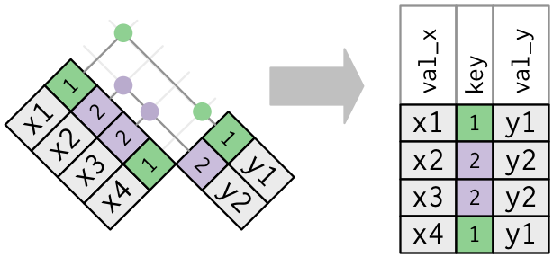

# Left/right outer joins

- All rows from the “left”/“right” table, even if there are no matching rows from the other

```r
students %>% left_join(grades)
```

```
## # A tibble: 7 × 4
##     sid  name grade course
##   <dbl> <chr> <dbl>  <chr>
## 1   100   Ann   8.0    A94
## 2   100   Ann   9.0    B90
## 3   101   Bob   6.5    A94
## 4   102   Cam   7.5    C14
## 5   103   Dee   7.0    A94
## 6   103   Dee   5.5    B90
## 7   104   Els    NA   <NA>
```

```r
students %>% right_join(grades)
```

```
## # A tibble: 7 × 4
##     sid  name grade course
##   <dbl> <chr> <dbl>  <chr>
## 1   100   Ann   8.0    A94
## 2   101   Bob   6.5    A94
## 3   103   Dee   7.0    A94
## 4   100   Ann   9.0    B90
## 5   103   Dee   5.5    B90
## 6   102   Cam   7.5    C14
## 7    90  <NA>   7.0    C14
```

# Full outer join

- All rows from each table

```r
students %>% full_join(grades)
```

```
## # A tibble: 8 × 4
##     sid  name grade course
##   <dbl> <chr> <dbl>  <chr>
## 1   100   Ann   8.0    A94
## 2   100   Ann   9.0    B90
## 3   101   Bob   6.5    A94
## 4   102   Cam   7.5    C14
## 5   103   Dee   7.0    A94
## 6   103   Dee   5.5    B90
## 7   104   Els    NA   <NA>
## 8    90  <NA>   7.0    C14
```


# Join excercies (Tasks 12–14)

```r
install.packages("nycflights13")
library(nycflights13)
```

# Reading data

- Focus in this course is on web scraping and API calls (covered in next session)
- Here I will briefly mention three packages that are used to read tabular data
  - If you have specific questions or need examples, let me know…

# readr

```r
library(readr)
```

- For reading delimited text files representing tabular (i.e. rectangular) data
- `readr::read_csv` instead of `base::read.csv`
- Very fast, with better defaults, good detection of special data (e.g., dates)

# readxl and haven

```r
install.packges("readxl", dependencies = TRUE)
library(readxl)
```

- For reading Excel spreadsheets

```r
install.packages("haven", dependencies = TRUE)
library(haven)
```

- For reading SAS, STAT, and SPSS data files
- Has some limited ability to write to these formats as well

# This week: Preliminary work for next week’s session (Twitter)

- Follow [this tutorial](http://bigcomputing.blogspot.nl/2016/02/the-twitter-r-package-by-jeff-gentry-is.html) which provides detailed instructions for setting up programmatic access to Twitter.
- Specifically, do the following **before our next session** (but follow the detailed instructions in the tutorial):
  1. `install.packages('twitteR', dependencies = TRUE)`
  2. [Create a Twitter account](http://twitter.com/signup) if you do not already have one
  3. Visit the [Twitter apps](https://apps.twitter.com) site and create a new app
  4. Create and record the four variables needed to access the Twitter API, and insert them into the code below to verify everything is working without error

```r
library(twitteR)
setup_twitter_oauth("your_consumer_key", "your_consumer_secret",
    "your_access_token", "your_access_secret")
searchTwitter(searchString = "#hashtag", n = 100, lang = "en",
    since = NULL, until = NULL, locale = NULL, geocode = NULL,
    sinceID = NULL, maxID = NULL, resultType = "recent",
    retryOnRateLimit = 120)
```

# This week: Preliminary work for next week’s session (HTML)

- Do all of the following **before our next session**
- Make sure `rvest` is installed:

```r
install.packages("rvest", dependencies = TRUE)
```

- [Play this game](http://flukeout.github.io) to learn CSS
- Install [SelectorGadget](https://chrome.google.com/webstore/detail/selectorgadget/mhjhnkcfbdhnjickkkdbjoemdmbfginb/related) for Chrome and try it, or else do a lot of playing around with “Inspect Element” in your favorite browser

# This week: Write some code and share it

- Be sure `readr` is installed:

```r
install.packages("readr", dependencies = TRUE)
```

- Create a new repository on github and then create a corresponding project in R (follow instructions from Session 1 slides)
- Create an R Markdown file, and in that file, download, clean up, and visualize some data. Download data that would be relevant to your research — if you need inspiration, visit this list of [awesome public datasets](https://github.com/caesar0301/awesome-public-datasets)
- Email the URL of your repository to another student (e.g., https://github.com/jasonmtroos/rook)
- Also email the URL of your repository to me

# This week: Run somebody else’s code and send them feedback

- After you receive an email from another student, clone their repository

```bash
$ cd "name of your git workspace folder goes here"
$ git clone "url to your colleague's github repository"
```

- Locate and open the `.Rproj` file and try to `knit` their R Markdown file
- Did it work? Yes? then great!
  - Send them feedback about their R Markdown file
  - Did you think it was readable?
  - Did the code make sense to you before you ran it? Not at all?

# This week: Want more practice?

- Visit these sites, read them, and write some code
  1. [ggplot2 documentation](http://docs.ggplot2.org/current/)
  2. [Chapter 3 of R for Data Science (visualization)](http://r4ds.had.co.nz/data-visualisation.html)
  3. [Chapter 14 of R for Data Science (functions)](http://r4ds.had.co.nz/functions.html)
  4. [Chapter 16 of R for Data Science (iteration)](http://r4ds.had.co.nz/iteration.html)